# Workshop 3 [Week 6] linear regression

# Predict and plot with ggplot

# add ‘fit’, ‘lwr’, and ‘upr’ columns to dataframe (generated by predict)

```r
old.predict <- cbind(faithful, predict(faithful.lm, interval = 'confidence'))
```

# plot the points (actual observations), regression line, and confidence interval

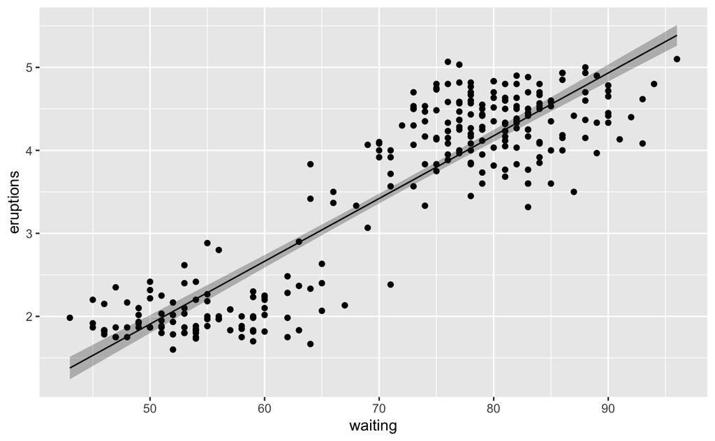

```r
p <- ggplot(old.predict, aes(waiting,eruptions))
p <- p + geom_point()
p <- p + geom_line(aes(waiting, fit))
p <- p + geom_ribbon(aes(ymin=lwr,ymax=upr), alpha=0.3)
p
```

# 2. Mussel dataset using abundance as a response variable

# load data file

```r
Mussel <- read.csv("Mussel.csv")
```

# Look at it

```r
glimpse(Mussel)
```

```
Rows: 25
Columns: 3
$ AREA    <dbl> 516.00, 469.06, 462.25, 938.60, 1357.15, 1773.66, 1686.01, 1786.29, 3090.0…
$ SPECIES <int> 3, 7, 6, 8, 10, 9, 10, 11, 16, 9, 13, 14, 12, 14, 20, 22, 15, 20, 22, 21, …
$ INDIV   <int> 18, 60, 57, 100, 48, 118, 148, 214, 225, 283, 380, 278, 338, 274, 569, 509…
```

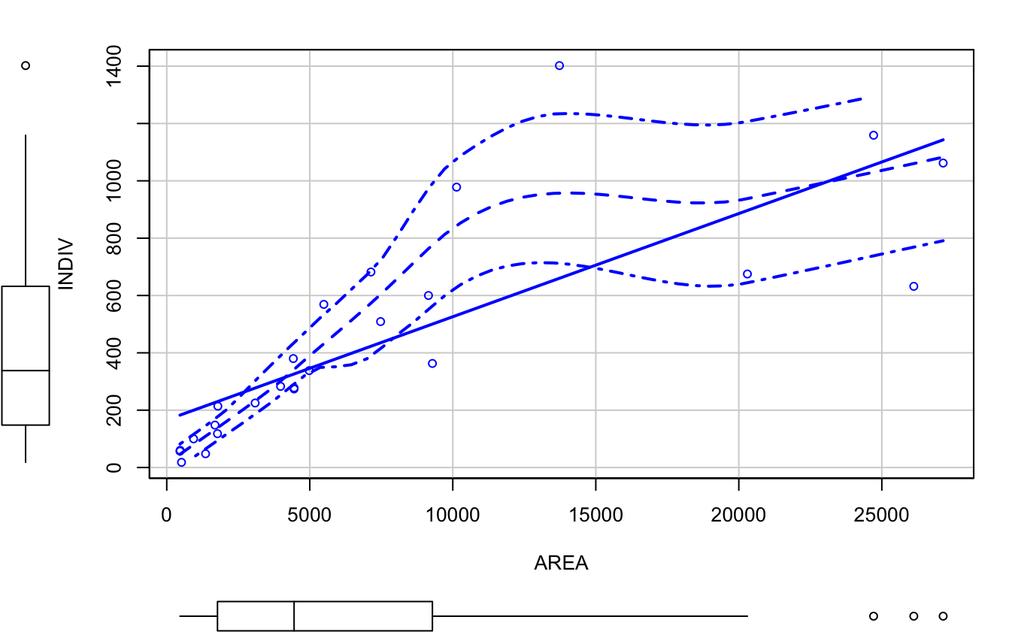

```r
scatterplot(INDIV ~ AREA, data = Mussel)
```

# This indicates that the data are not normaly disributed (especially AREA)

# The abundance data don’t look too good either. Huge peak in the middle

# Let’s fit a linear model nonetheless and look at it

```r
mussel.lm <- lm(INDIV ~ AREA, data = Mussel)
summary(mussel.lm)
```

```
Call:
lm(formula = INDIV ~ AREA, data = Mussel)

Residuals:
    Min      1Q  Median      3Q     Max
-474.19 -122.92  -52.25   73.85  741.76

Coefficients:
            Estimate Std. Error t value Pr(>|t|)
(Intercept) 166.0341    66.3488   2.502   0.0199 *
AREA          0.0360     0.0059   6.101 3.18e-06 ***
---
Signif. codes:  0 ‘***’ 0.001 ‘**’ 0.01 ‘*’ 0.05 ‘.’ 0.1 ‘ ’ 1

Residual standard error: 238.9 on 23 degrees of freedom
Multiple R-squared:  0.6181,    Adjusted R-squared:  0.6015
F-statistic: 37.23 on 1 and 23 DF,  p-value: 3.183e-06
```

# Area looks to significantly related to the number of mussels

# Now check assumption by using R’s inbuilt model validation plot defaults

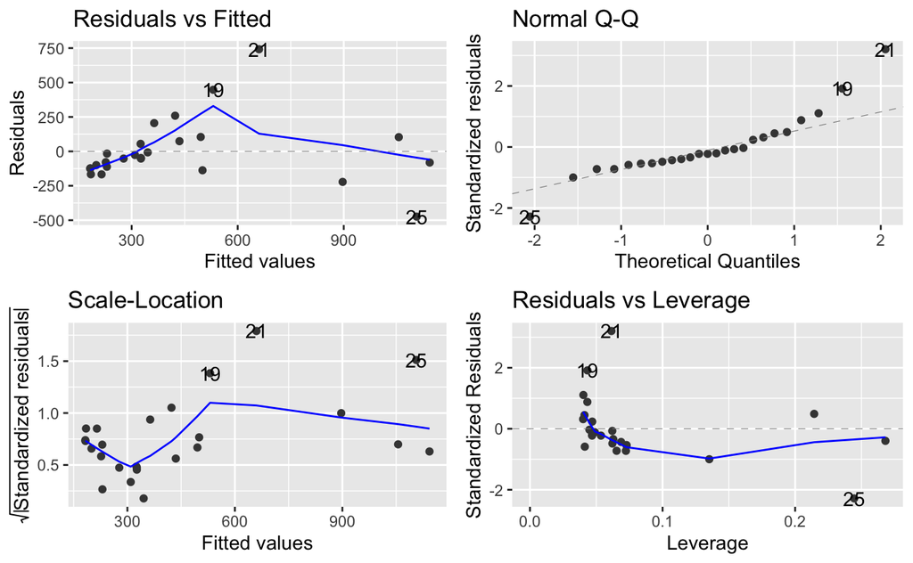

```r
autoplot(mussel.lm)
```

# Residuals v Fitted indicate a problem. It’s wedge shaped and humped!

# qqplot is a bit dodgy but might be okay

# Scale-Location plot indicates a wedge

# Cook distance / leverage looks okay - but there are some large values in area

# FINAL VALIDATION TASK - residuals against explanatory variable

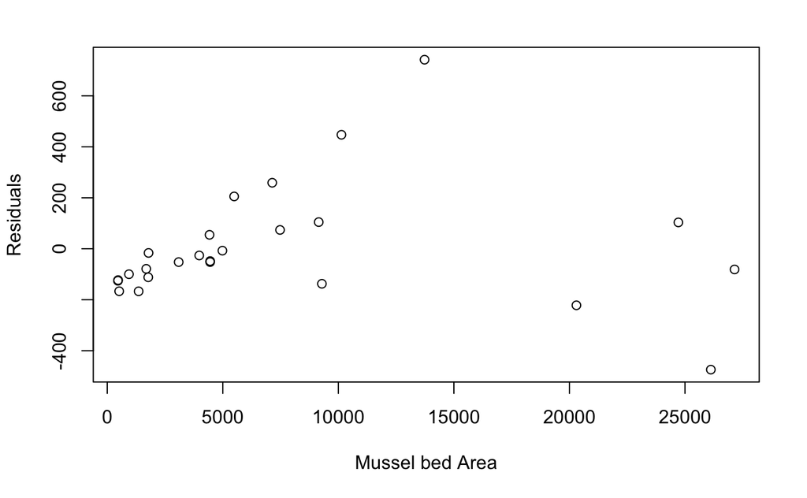

```r
plot(mussel.lm$resid ~ Mussel$AREA,
     xlab = "Mussel bed Area",
     ylab = "Residuals")
```

# Some code for ggplot to do the same thing…..

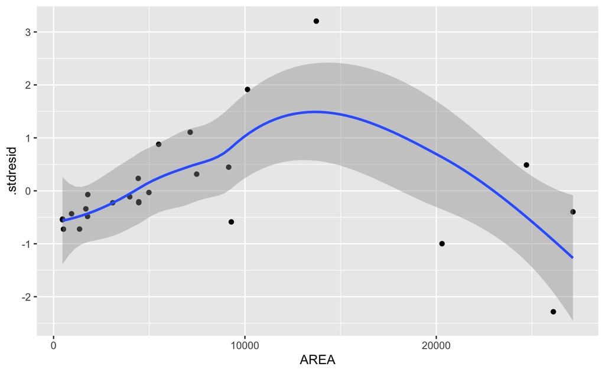

```r
ggplot(fortify(mussel.lm, Mussel), aes(AREA, .stdresid)) +
  geom_point() + geom_smooth(se = TRUE)
```

# This indicates a few large values and a slight wedge due to numerous small patches

# Conclusion we reject the model

# We can linearise the explanatory variables by transforming them and re-run the model

# I am not a fan of this - we’ll look at other approaches in the coming weeks!

# and repeat the validation

# Let’s fit a linear model nonetheless and look at it

```r
mussel.lm1 <- lm(INDIV ~ log10(AREA), data = Mussel)
summary(mussel.lm1)
```

```
Call:
lm(formula = INDIV ~ log10(AREA), data = Mussel)

Residuals:
    Min      1Q  Median      3Q     Max
-283.26 -147.33  -63.45  108.26  656.14

Coefficients:
            Estimate Std. Error t value Pr(>|t|)
(Intercept) -1681.92     300.05  -5.605 1.05e-05 ***
log10(AREA)   586.75      81.85   7.169 2.67e-07 ***
---
Signif. codes:  0 ‘***’ 0.001 ‘**’ 0.01 ‘*’ 0.05 ‘.’ 0.1 ‘ ’ 1

Residual standard error: 215 on 23 degrees of freedom
Multiple R-squared:  0.6908,    Adjusted R-squared:  0.6774
F-statistic: 51.39 on 1 and 23 DF,  p-value: 2.671e-07
```

# Now check assumption by using R’s inbuilt model validation plot defaults

# set graphics parameters because we want all the plots on one graphic

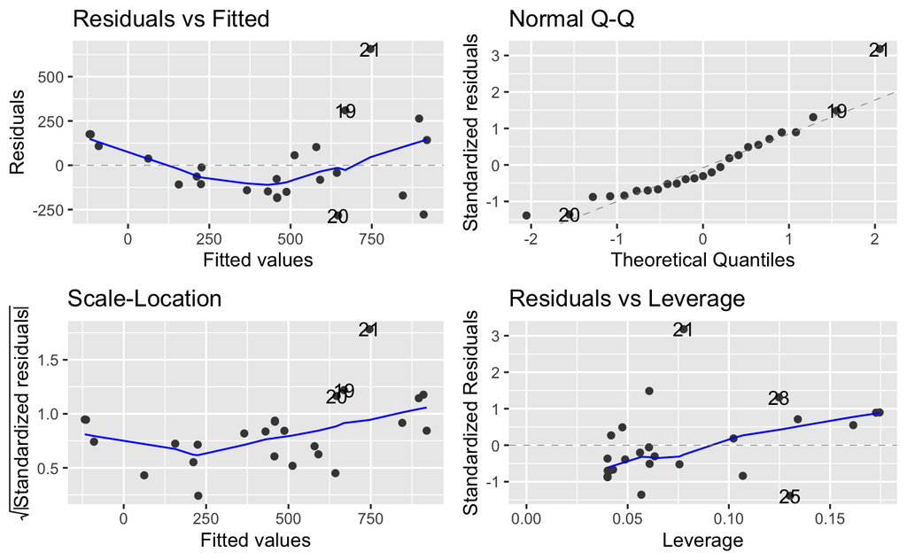

```r
autoplot(mussel.lm1)
```

# Residuals v Fitted are better but there is still a bit of wedge at higher fitted values

# Scale-Location plot indicates a slight wedge with higher values

# Cook distance / leverage looks improved

# FINAL VALIDATION TASK - residuals against explanatory variable

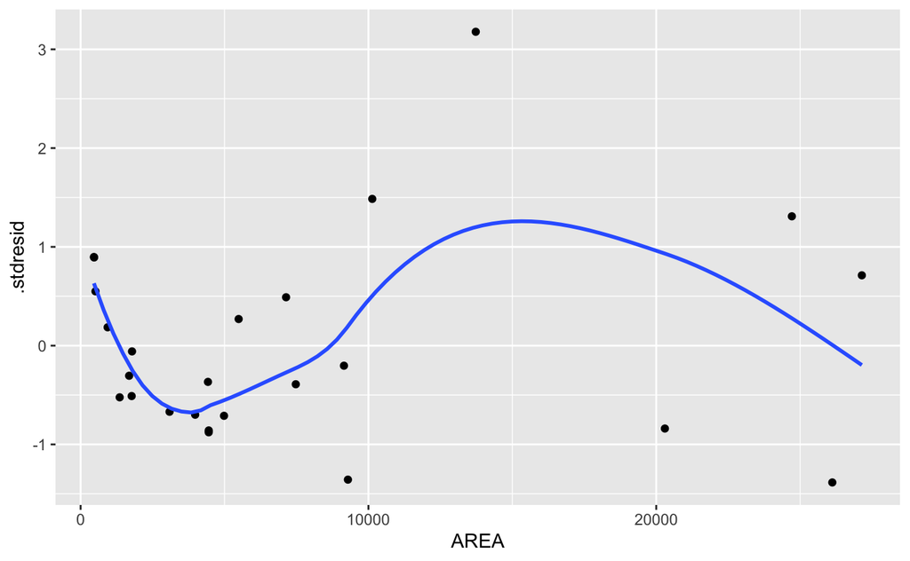

```r
ggplot(fortify(mussel.lm1, Mussel), aes(AREA, .stdresid)) +
  geom_point() + geom_smooth(se = FALSE)
```

# This indicates a few large values and a slight wedge due to numerous small patches

# Conclusion we reject the model

# Try log10 on the response - not unusual with abundance data.

# There are no zeros so we don’t need an offset of 0.01 or something similar

# fit a linear model - there are other ways of dealing with this. We’ll get to them later in the series of workshops

```r
mussel.lm2 <- lm(log10(INDIV) ~ log10(AREA), data = Mussel)
summary(mussel.lm2)
```

```
Call:
lm(formula = log10(INDIV) ~ log10(AREA), data = Mussel)

Residuals:
     Min       1Q   Median       3Q      Max
-0.43355 -0.06464  0.02219  0.11178  0.26818

Coefficients:
            Estimate Std. Error t value Pr(>|t|)
(Intercept) -0.57601    0.25904  -2.224   0.0363 *
log10(AREA)  0.83492    0.07066  11.816 3.01e-11 ***
---
Signif. codes:  0 ‘***’ 0.001 ‘**’ 0.01 ‘*’ 0.05 ‘.’ 0.1 ‘ ’ 1

Residual standard error: 0.1856 on 23 degrees of freedom
Multiple R-squared:  0.8586,    Adjusted R-squared:  0.8524
F-statistic: 139.6 on 1 and 23 DF,  p-value: 3.007e-11
```

# Now check assumption

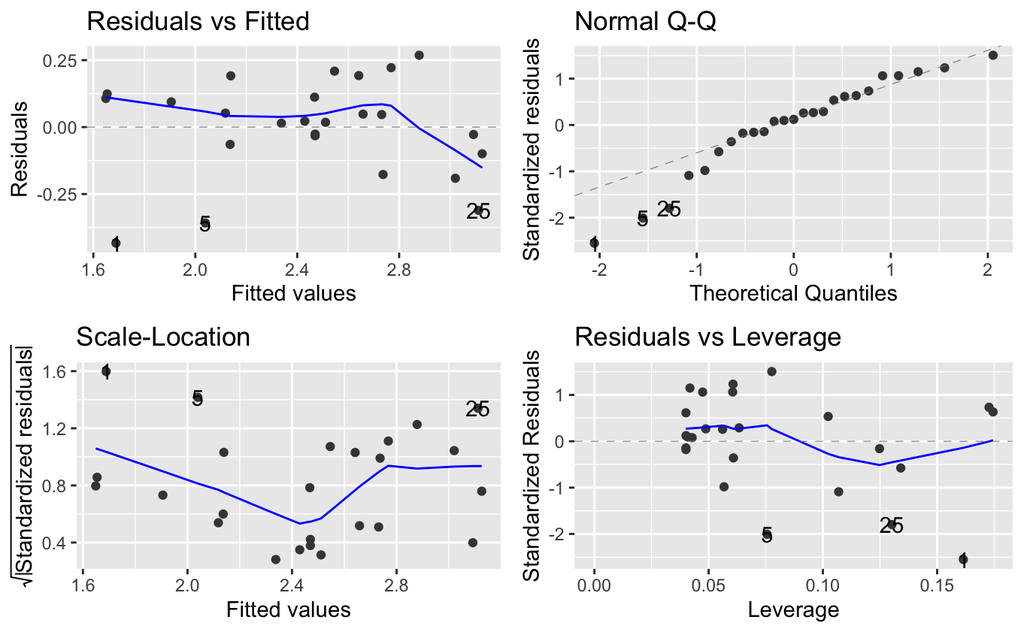

```r
autoplot(mussel.lm2)
```